# Hard Work 1

## Instructions

1. Study Sections 1-5 of Chapter 1 – “Linear Regression with One Predictor Variable.”  
   (You may also choose to study Sections 6-8 if you are interested in the theory behind regression.)
2. Attempt and submit at least {24} Hard Work Points by Saturday at 11:59 PM.  
   Over {30} gets you {+1} Final Exam Point.  
   Over {40} gets you {+2} Final Exam Points.  
   Over {50} gets you {+3} Final Exam Points.

{…} are “Recommended” and will earn you the minimum points required.

{…} are optional, but the more of these you complete, the better.

The format of reporting your score on each problem is:

**{ Attempted Points “A=” | Earned Points “E=” }**

- **Attempted Points**: You gave the problem your time and energy, but aren’t sure if you are completing the problem correctly or not. You will be graded on what you attempt.
- **Earned Points**: You are confident you have completed the problem correctly by comparing your work to the [Student Solutions](http://fac.ksu.edu.sa/sites/default/files/1_58.pdf), other students in class, or the examples in the book. This should always be less than or equal to **Attempted Points**.

By marking points in this way, your teacher can identify problems that you are working on, but having difficulty with, and can help you and the class better understand those concepts.

## Reading Points {21} Possible

### Section 1.1 {3}{ A=3 | E=2 }

### Section 1.2 {3}{ A=3 | E=2 }

### Section 1.3 {3}{ A=3 | E=2 }

### Section 1.4 {2}{ A=2 | E=1 }

### Section 1.5 {2}{ A=2 | E=1 }

### Section 1.6 {3}{ A=0 | E=0 }

### Section 1.7 {2}{ A=0 | E=0 }

### Section 1.8 {3}{ A=0 | E=0 }

## Theory Points {11} Possible

### Problem 1 {3}{ A=3 | E=2 }

Recreate this chalkboard in your own handwriting

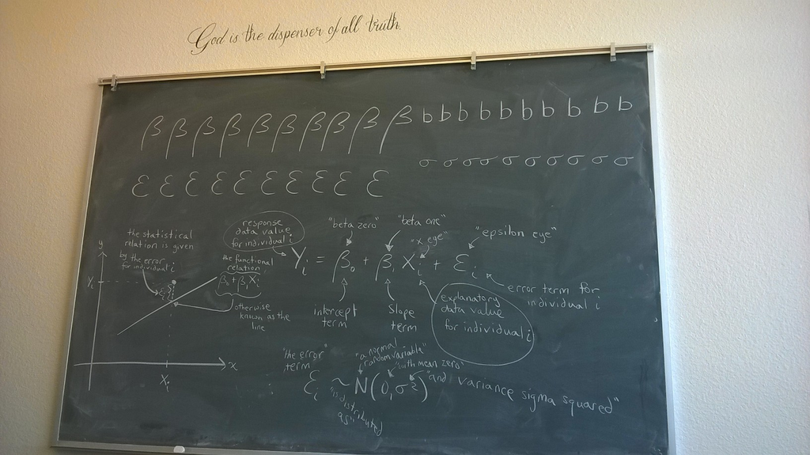

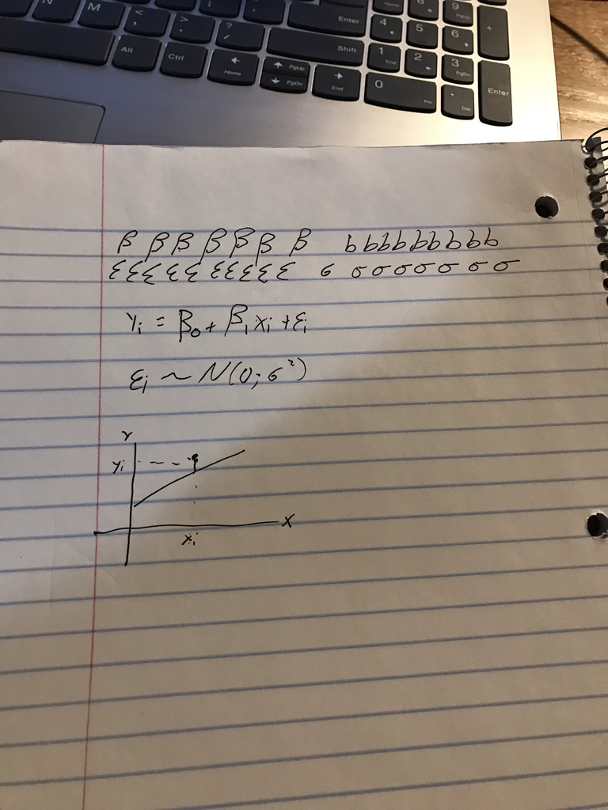

### Problems 1.29 and 1.30 {2}{ A=0 | E=0 }

### Problem 1.32 {2}{ A=0 | E=0 }

### Problem 1.33 {4}{ A=0 | E=0 }

### Problem 1.34 {3}{ A=0 | E=0 }

## Application Points {19} Possible

[Download Data Files](http://www.stat.ufl.edu/~rrandles/sta4210/Rclassnotes/data/textdatasets/index.html)

### Problem 1.19 {4}{ A=4 | E=2 }

```r
# Load the Problem 1.19 Data into the object "p1.19":
p1.19 <- read.table("http://www.stat.ufl.edu/~rrandles/sta4210/Rclassnotes/data/textdatasets/KutnerData/Chapter%20%201%20Data%20Sets/CH01PR19.txt")

# Rewrite the column names to be "Y" and "X" to match the textbook:
colnames(p1.19) <- c("Y","X")
```

```r
library(tidyverse)
```

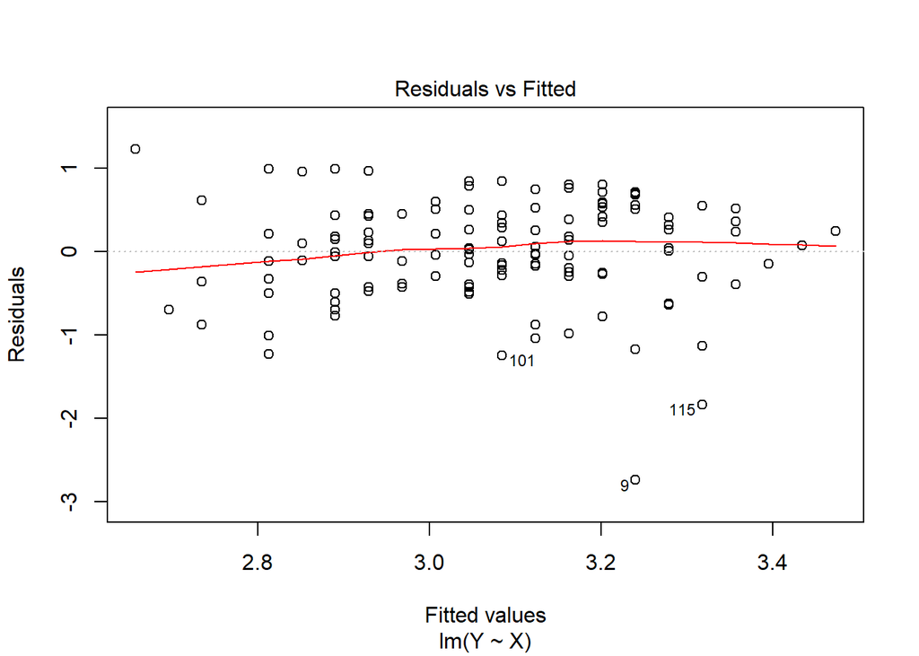

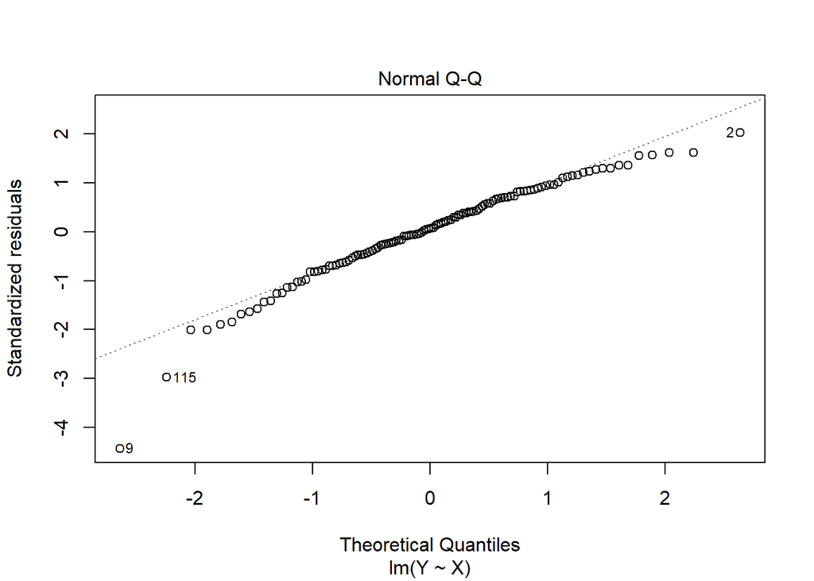

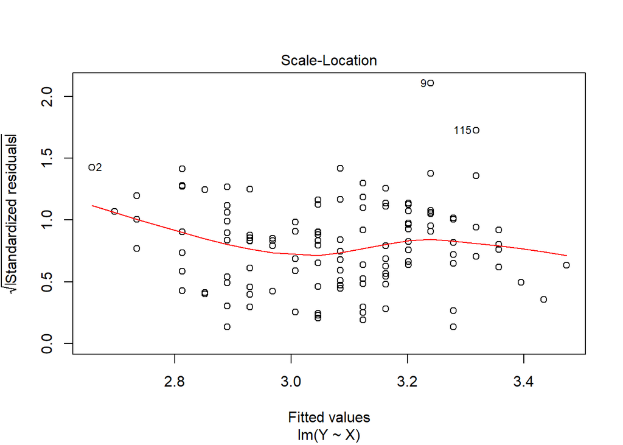

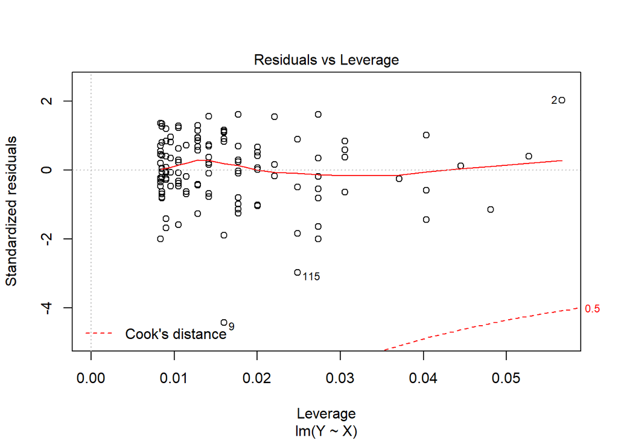

```r
my_lm <- lm(Y~X, data = p1.19)

#2.11404929+0.03882713*x = y


my_coef <- coef(my_lm)
View(my_coef)

plot(my_lm)
```

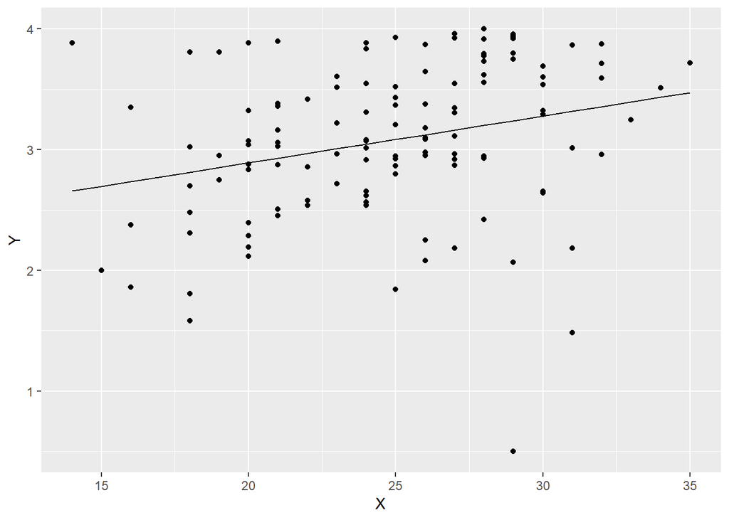

```r
p1.19 %>%
  mutate(pred = coef(my_lm)[1]+coef(my_lm)[2] * X) %>%
  ggplot()+
  geom_point(aes(x=X, y = Y))+
  geom_line(aes(x=X,y=pred))
```

```r
coef(my_lm)[2]
```

```
##          X
## 0.03882713
```

### Problem 1.20 {4}{ A=4 | E=3 }

```r
# Load the Data:
p1.20 <- read.table("http://www.stat.ufl.edu/~rrandles/sta4210/Rclassnotes/data/textdatasets/KutnerData/Chapter%20%201%20Data%20Sets/CH01PR20.txt")

# Rewrite the column names to be "Y" and "X" to match the textbook:
colnames(p1.20) <- c("Y","X")
```

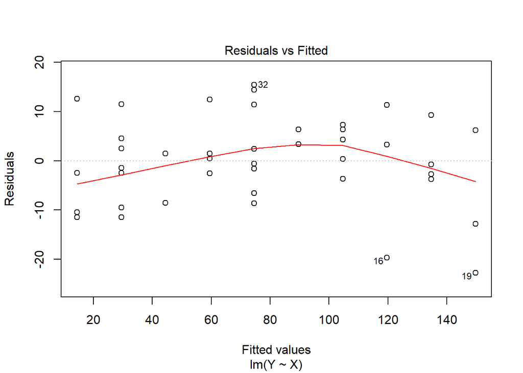

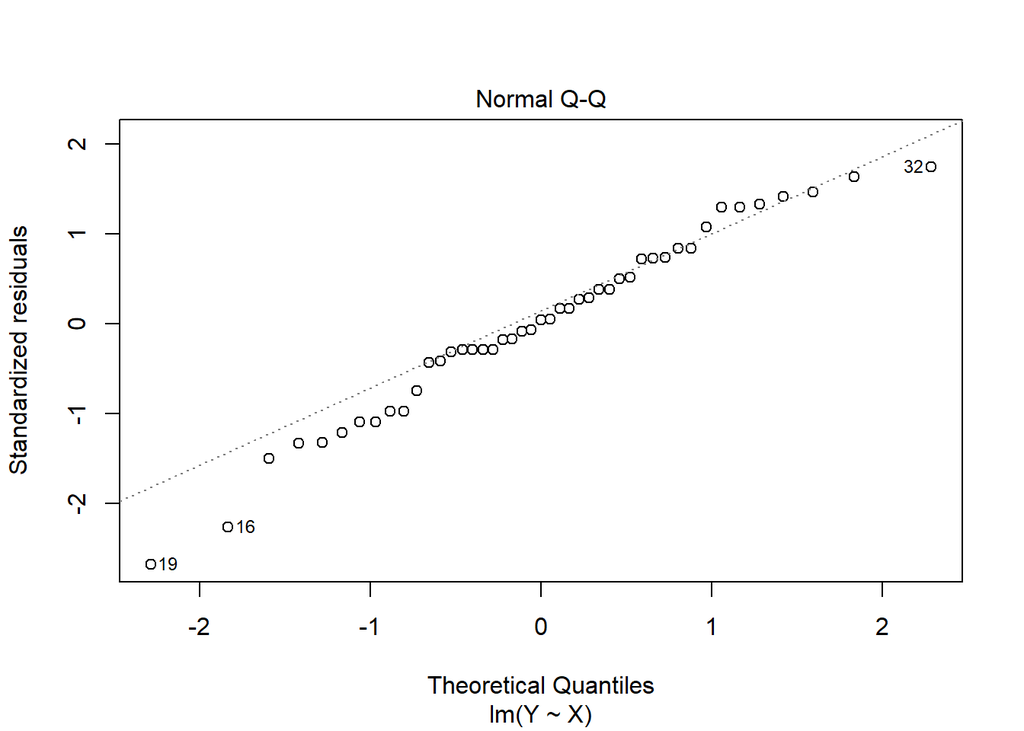

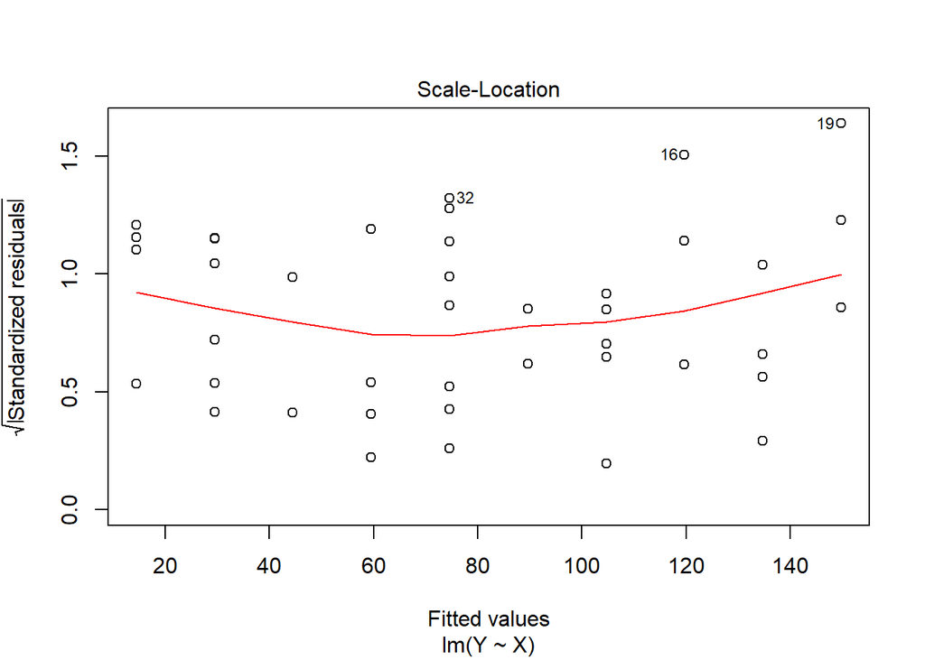

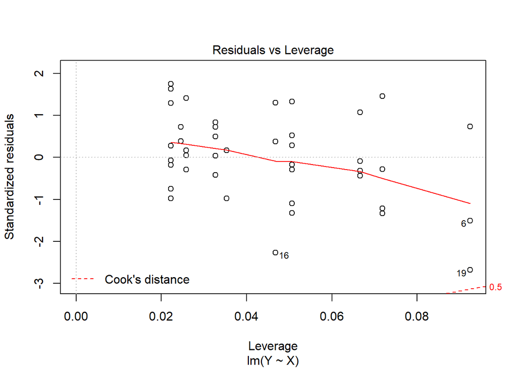

```r
my_lm2 <- lm(Y~X, data = p1.20)

#-.5801567+15.0352480 * x = y


my_coef2 <- coef(my_lm2)
View(my_coef2)

plot(my_lm2)
```

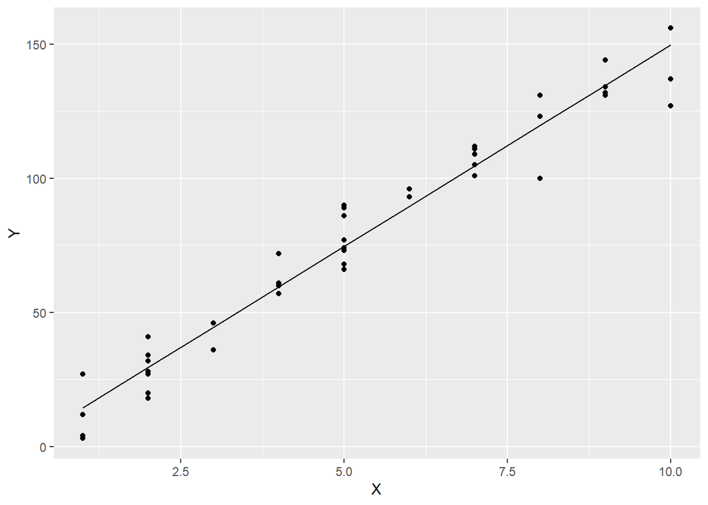

```r
p1.20 %>%
  mutate(pred = coef(my_lm2)[1]+coef(my_lm2)[2] * X) %>%
  ggplot()+
  geom_point(aes(x=X, y = Y))+
  geom_line(aes(x=X,y=pred))
```

```r
coef(my_lm2)[2]
```

```
##        X
## 15.03525
```

```r
#c. gives you information but it is not well understood and does not make sense with it being negative.

#D. 75
```

### Problem 1.21 {4}{ A=0 | E=0 }

```r
# Load the Data:
p1.21 <- read.table("http://www.stat.ufl.edu/~rrandles/sta4210/Rclassnotes/data/textdatasets/KutnerData/Chapter%20%201%20Data%20Sets/CH01PR21.txt")

# Rewrite the column names to be "Y" and "X" to match the textbook:
colnames(p1.21) <- c("Y","X")
```

### Problem 1.22 {3}{ A=0 | E=0 }

```r
# Load the Data:
p1.22 <- read.table("http://www.stat.ufl.edu/~rrandles/sta4210/Rclassnotes/data/textdatasets/KutnerData/Chapter%20%201%20Data%20Sets/CH01PR22.txt")

# Rewrite the column names to be "Y" and "X" to match the textbook:
colnames(p1.22) <- c("Y","X")
```

### Problem 1.27 {2}{ A=0 | E=0 }

```r
# Load the Data:
p1.27 <- read.table("http://www.stat.ufl.edu/~rrandles/sta4210/Rclassnotes/data/textdatasets/KutnerData/Chapter%20%201%20Data%20Sets/CH01PR27.txt")

# Rewrite the column names to be "Y" and "X" to match the textbook:
colnames(p1.27) <- c("Y","X")
```

### Problem 1.28 {2}{ A=0 | E=0 }

```r
# Load the Data:
p1.28 <- read.table("http://www.stat.ufl.edu/~rrandles/sta4210/Rclassnotes/data/textdatasets/KutnerData/Chapter%20%201%20Data%20Sets/CH01PR28.txt")

# Rewrite the column names to be "Y" and "X" to match the textbook:
colnames(p1.28) <- c("Y","X")
```